# Problem Set 3 - Exponential Growth

[EFB 370: Population Ecology](https://eligurarie.github.io/EFB370/)

#### Due date: Thursday, February 27, 2025 at midnight

#### Total Points: 20 (with several extra credit problems)

> *Instructions:*
- *Submit this homework as a document. It can be entirely typed on a computer and uploaded on Blackboard, or completed as a combination of handwritten and printed (computer generated plots must be printed).*
- *Answer questions in complete sentences and explain how you obtained your answers. Only provide answers and include plots,* **do NOT send in code!**
- *Collaboration and discussion - openly and on the discussion forum - is highly encouraged, but do not provide and publicize answers.*

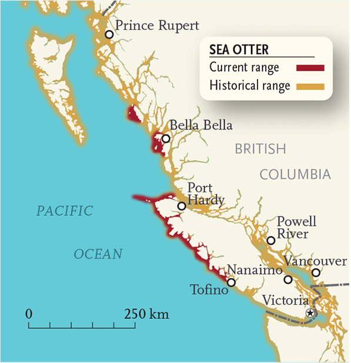

## I. BC sea otters (8 pts)

Sea otters were completely wiped out in British Columbia, Canada, much as in Washington and Oregon states. The Department of Fish and Oceans, Canada, reports count data from annual surveys - similar to the Washington State data. The raw data can be downloaded here: https://open.canada.ca/data/en/dataset/90081ffa-60fb-47d1-a1fe-c279e42dda47 Cleaned up version of the data is uploaded to Blackboard as `BC_SeaOtters.csv` or at this link.

1. (**1 pt**) How many sea otters were released and in what year? What is the last year of observations and how many sea otters were there then?
2. (1 pt) Plot the population trajectory in time with and without a log-transformation. Comment on whether the growth looks linear, exponential or logistic. What do you base that assessment on?
3. (2 pt) Using the **first** and **last** values of these data, compute a discrete multiplicative growth rate $\lambda$ by using the formula
   $$N_t = N_0 \lambda^t.$$
   How does that translate into an *annual* growth rate, i.e. by what percentage does the population increase by annually? What is the *instantaneous growth rate* $r$, i.e. from the continuous time formulation:
   $$N(t) = N_0
   e^{rt}.$$
   How do these growth rates compare with the growth rate we computed for sea otters in Washington State?

3b. (**Extra Credit**) Estimate the instrisic growth rate $r$ using ALL the data by fitting a linear model of *log(Count)* against Year. Obtain a 95% confidence interval around that estimate.

4. (1 pt) The data are only provided through 2013. Assuming that this growth rate calculated in 3 stays constant, how many sea otters are expected to be in BC in 2017?
5. (1 pt) The actual number of sea otters in the most recent survey I could find (2017) was 8110 (see Table 2 in the document on [this page](https://www.dfo-mpo.gc.ca/csas-sccs/Publications/SAR-AS/2020/2020_036-eng.html)). Given your analysis above, what does that tell you about sea otter population growth in BC?

5b. (**Extra credit:**) In an analysis of population growth trends, researchers determined that the population growth rate of sea otters in BC changed around 1995. Obtain the intrinsic growth rate ($r$) before and after 1995, with 95% confidence intervals around the estimate. Convert those to annual growth rates.

*Hint:* *To subset a data frame in R, use the `subset()` function, for example:*

```r
BC_early <- subset(BC, Year <= 1995)
```

*The `<=` notation means “less than or equal to”*

6. (2 pts) The analysis above suggests that sea otter population growth (like any multiplicative population growth) cannot continue indefinitely. Why might population growth rate be slowing down? Propose some ecological mechanisms (hypotheses) that might explain a slowing growth rate. What kind of data might you collect to explore those hypotheses?

## II. Stochastic Sea Otters (5 pts)

The (annual) survival rate of sea otters is about 90%. Assume it has not changed in the past 50 years. Use the demographic stochasticity app at this link: https://egurarie.shinyapps.io/StochasticGrowth/ to

1. (2 pts) Match the observed growth of Washington sea otters (60 to 1000 in 40 years) by adjusting the (annual) probability of giving birth. Report that probability of giving birth, and the median and inter-quartile range of the final population. Note, if you increase the number of simulations (e.g. to 1000 from the default 100), the process will be a bit slower, but more consistent across repetitions. Save the image of your fit and include it in your document. Note: You can do this by right-clicking on a simulation result and clicking on “Save Image As”
2. (3 pts) Actual sea otter females almost never give birth to twins. We can assume, further, that the average sea otter lives 10 years, of which 5 are reproductive. Given these numbers (and the answer to part 1), what do you think the approximate probability that an adult reproductively viable female will give birth in a given year? Explain your reasoning. *This is a slightly tricky question with very easy arithmetic!*

[figure not shown]

*In the unlikely event you’re getting sick of sea otters, look at this picture:*

## III. Charles Darwin’s Elephants (7 pts)

Charles Darwin contemplated exponential growth in his *Origin of Species*. To make his point, he considered the slowest breeding animal he knew, the elephant. Here is the complete excerpt:

> There is no exception to the rule that every organic being increases at so high a rate, that if not destroyed, the earth would soon be covered by the progeny of a single pair … The elephant is reckoned to be the slowest breeder of all known animals, and I have taken some pains to estimate its probable minimum rate of natural increase: it will be under the mark to assume that it breeds when thirty years old, and goes on breeding till ninety years old, bringing forth three pairs of young in this interval; if this be so, at the end of the fifth century there would be alive fifteen million elephants, descended from the first pair.

So - Darwin is saying that it will take 500 years for the elephant population to grow from 2 to 15,000,000.

1.(1pt) Based on these numbers, what is the intrinsic growth rate $r$ for Darwin’s elephants?

2. (2 pts) If we make an assumption of constant mortality risk, an animal that lives 90 years has a per-year probability of death of $p_d = 1/90 = 0.01111$. If an elephant *pair* produces six offspring over 90 years of life, the individual per-year probability of birth is $p_b = 6/90/2 = 0.03333$. Plug those numbers into the stochastic demography calculator, and see how close Darwin’s estimate is.
3. (2 pts) Spoiler alert, it’s off. One might argue: way off. And Darwin didn’t show his work, so we don’t know how he came up with his numbers. How can you fix the birth and death probability to actually get 15,000,000 elephants after 500 years? Specifically, if we assume the 90 year life-span of the elephants is correct, how many offspring would a pair of elephants need to produce over their lifetime? Explain your reasoning.
4. (2 pts) Given the very very small size of Darwin’s initial population (1 pair), demographic stochasticity also plays an important role. Using Darwin’s number, what’s the probability that the whole population just goes extinct before getting anywhere within smelling distance of 15,000,000? What if you started with 10 elephants instead of 2? (I’d suggest using at least 1000 simulations to get at these estimates.)

[figure not shown]